# Cyclistic bike-share case study

Amith

2025-08-22

# 1. Business Task

Cyclistic’s marketing team has identified a key buiness opportunity: converting casual riders into annual members. Annual members generate more consistent revenue and are more porfitable than casual riders

**Business Task:**  
Analyze historical Cyclistic trip data to determine **how annual members and casual riders use Cyclistic bikes differently**.  
The insights will guide the marketing strategy to encourage casual riders to purchase annual memberships

**Key Stakeholders:**  
- **Lily Moreno (Director of Marketing):** Oversees marketing initiatives and campaigns.  
- **Cyclistic Marketing Analytics Team:** Responsible for analyzing rider behavior and providing insights.  
- **Cyclistic Executive Team:** Will review findings and approve the final marketing strategy.

# 2. Data Sources

For this case study, the analysis uses **Cyclistic’s historical trip data**, which is made publicly available by the Divvy bike-share system in Chicago.

- **Source:** [Divvy Trip Data Archive](https://divvy-tripdata.s3.amazonaws.com/index.html)
- **Provider:** Motivate International Inc., which operates the Divvy program.
- **License:** Public data license agreement. No personally identifiable information (PII) is included.

**Datasets Used:**  
Because this project is being run on **RStudio Cloud (Posit free account)** with memory limitations, the analysis focuses on two quarters of data:  
- `Divvy_Trips_2019_Q1.csv` (January–March 2019)  
- `Divvy_Trips_2020_Q1.csv` (January–March 2020)

# 3. Data Cleaning and Preparation (Process)

**Tools chosen:**  
The data was processed using **RStudio Cloud** with the `tidyverse` package for data manipulation and `lubridate` for working with dates. R was chosen because it can efficiently handle large datasets and supports reproducible workflows.

```r
install.packages("tidyverse")
install.packages("lubridate")
library(tidyverse)
library(lubridate)

# Import datasets

q1_2019 <- read_csv("data/Divvy_Trips_2019_Q1.csv")
q1_2020 <- read_csv("data/Divvy_Trips_2020_Q1.csv")
# Rename columns in 2019 to match 2020

q1_2019 <- q1_2019 %>%
  rename(ride_id = trip_id,
         started_at = start_time,
         ended_at = end_time,
         member_casual = usertype)

# Fix ride_id type before combining

q1_2019 <- q1_2019 %>%
  mutate(ride_id = as.character(ride_id))

q1_2020 <- q1_2020 %>%
  mutate(ride_id = as.character(ride_id))

print(q1_2020)
```

```
## # A tibble: 426,887 × 13
##    ride_id          rideable_type started_at          ended_at
##    <chr>            <chr>         <dttm>              <dttm>
##  1 EACB19130B0CDA4A docked_bike   2020-01-21 20:06:59 2020-01-21 20:14:30
##  2 8FED874C809DC021 docked_bike   2020-01-30 14:22:39 2020-01-30 14:26:22
##  3 789F3C21E472CA96 docked_bike   2020-01-09 19:29:26 2020-01-09 19:32:17
##  4 C9A388DAC6ABF313 docked_bike   2020-01-06 16:17:07 2020-01-06 16:25:56
##  5 943BC3CBECCFD662 docked_bike   2020-01-30 08:37:16 2020-01-30 08:42:48
##  6 6D9C8A6938165C11 docked_bike   2020-01-10 12:33:05 2020-01-10 12:37:54
##  7 31EB9B8F406D4C82 docked_bike   2020-01-10 13:07:35 2020-01-10 13:12:24
##  8 A2B24E3F9C9720E3 docked_bike   2020-01-10 07:24:53 2020-01-10 07:29:50
##  9 5E3F01E1441730B7 docked_bike   2020-01-31 16:37:16 2020-01-31 16:42:11
## 10 19DC57F7E3140131 docked_bike   2020-01-31 09:39:17 2020-01-31 09:42:40
## # ℹ 426,877 more rows
## # ℹ 9 more variables: start_station_name <chr>, start_station_id <dbl>,
## #   end_station_name <chr>, end_station_id <dbl>, start_lat <dbl>,
## #   start_lng <dbl>, end_lat <dbl>, end_lng <dbl>, member_casual <chr>
```

```r
# Combine datasets

trips <- bind_rows(q1_2019, q1_2020)

print(trips)
```

```
## # A tibble: 791,956 × 21
##    ride_id  started_at          ended_at            bikeid tripduration
##    <chr>    <dttm>              <dttm>               <dbl>        <dbl>
##  1 21742443 2019-01-01 00:04:37 2019-01-01 00:11:07   2167          390
##  2 21742444 2019-01-01 00:08:13 2019-01-01 00:15:34   4386          441
##  3 21742445 2019-01-01 00:13:23 2019-01-01 00:27:12   1524          829
##  4 21742446 2019-01-01 00:13:45 2019-01-01 00:43:28    252         1783
##  5 21742447 2019-01-01 00:14:52 2019-01-01 00:20:56   1170          364
##  6 21742448 2019-01-01 00:15:33 2019-01-01 00:19:09   2437          216
##  7 21742449 2019-01-01 00:16:06 2019-01-01 00:19:03   2708          177
##  8 21742450 2019-01-01 00:18:41 2019-01-01 00:20:21   2796          100
##  9 21742451 2019-01-01 00:18:43 2019-01-01 00:47:30   6205         1727
## 10 21742452 2019-01-01 00:19:18 2019-01-01 00:24:54   3939          336
## # ℹ 791,946 more rows
## # ℹ 16 more variables: from_station_id <dbl>, from_station_name <chr>,
## #   to_station_id <dbl>, to_station_name <chr>, member_casual <chr>,
## #   gender <chr>, birthyear <dbl>, rideable_type <chr>,
## #   start_station_name <chr>, start_station_id <dbl>, end_station_name <chr>,
## #   end_station_id <dbl>, start_lat <dbl>, start_lng <dbl>, end_lat <dbl>,
## #   end_lng <dbl>
```

```r
# Add ride_length & day_of_week

trips <- trips %>%
  mutate(ride_length = as.numeric(difftime(ended_at, started_at, units = "mins")),
         day_of_week = wday(started_at, label = TRUE))


# Remove bad data

trips_clean <- trips %>%
  filter(ride_length > 0 & !is.na(ride_length))

# Preview cleaned dataset

glimpse(trips_clean)
```

```
## Rows: 791,746
## Columns: 23
## $ ride_id            <chr> "21742443", "21742444", "21742445", "21742446", "21…
## $ started_at         <dttm> 2019-01-01 00:04:37, 2019-01-01 00:08:13, 2019-01-…
## $ ended_at           <dttm> 2019-01-01 00:11:07, 2019-01-01 00:15:34, 2019-01-…
## $ bikeid             <dbl> 2167, 4386, 1524, 252, 1170, 2437, 2708, 2796, 6205…
## $ tripduration       <dbl> 390, 441, 829, 1783, 364, 216, 177, 100, 1727, 336,…
## $ from_station_id    <dbl> 199, 44, 15, 123, 173, 98, 98, 211, 150, 268, 299, …
## $ from_station_name  <chr> "Wabash Ave & Grand Ave", "State St & Randolph St",…
## $ to_station_id      <dbl> 84, 624, 644, 176, 35, 49, 49, 142, 148, 141, 295, …
## $ to_station_name    <chr> "Milwaukee Ave & Grand Ave", "Dearborn St & Van Bur…
## $ member_casual      <chr> "Subscriber", "Subscriber", "Subscriber", "Subscrib…
## $ gender             <chr> "Male", "Female", "Female", "Male", "Male", "Female…
## $ birthyear          <dbl> 1989, 1990, 1994, 1993, 1994, 1983, 1984, 1990, 199…
## $ rideable_type      <chr> NA, NA, NA, NA, NA, NA, NA, NA, NA, NA, NA, NA, NA,…
## $ start_station_name <chr> NA, NA, NA, NA, NA, NA, NA, NA, NA, NA, NA, NA, NA,…
## $ start_station_id   <dbl> NA, NA, NA, NA, NA, NA, NA, NA, NA, NA, NA, NA, NA,…
## $ end_station_name   <chr> NA, NA, NA, NA, NA, NA, NA, NA, NA, NA, NA, NA, NA,…
## $ end_station_id     <dbl> NA, NA, NA, NA, NA, NA, NA, NA, NA, NA, NA, NA, NA,…
## $ start_lat          <dbl> NA, NA, NA, NA, NA, NA, NA, NA, NA, NA, NA, NA, NA,…
## $ start_lng          <dbl> NA, NA, NA, NA, NA, NA, NA, NA, NA, NA, NA, NA, NA,…
## $ end_lat            <dbl> NA, NA, NA, NA, NA, NA, NA, NA, NA, NA, NA, NA, NA,…
## $ end_lng            <dbl> NA, NA, NA, NA, NA, NA, NA, NA, NA, NA, NA, NA, NA,…
## $ ride_length        <dbl> 6.500000, 7.350000, 13.816667, 29.716667, 6.066667,…
## $ day_of_week        <ord> Tue, Tue, Tue, Tue, Tue, Tue, Tue, Tue, Tue, Tue, T…
```

```r
# 4. Analysis

##Average Ride Length

  trips_clean %>%
  group_by(member_casual) %>%
  summarise(avg_ride_length = mean(ride_length),
            median_ride_length = median(ride_length),
            max_ride_length = max(ride_length))
```

```
## # A tibble: 4 × 4
##   member_casual avg_ride_length median_ride_length max_ride_length
##   <chr>                   <dbl>              <dbl>           <dbl>
## 1 Customer                 61.9              23.4          177200.
## 2 Subscriber               13.9               8.35         101607.
## 3 casual                   96.2              21.3          156450.
## 4 member                   12.7               8.58          93794.
```

```r
##Number of Rides by User Type

  trips_clean %>%
  group_by(member_casual) %>%
  summarise(number_of_rides = n())
```

```
## # A tibble: 4 × 2
##   member_casual number_of_rides
##   <chr>                   <int>
## 1 Customer                23163
## 2 Subscriber             341906
## 3 casual                  48270
## 4 member                 378407
```

```r
## Rides by Day of Week

  trips_clean %>%
  group_by(member_casual, day_of_week) %>%
  summarise(number_of_rides = n(),
            avg_ride_length = mean(ride_length)) %>%
  arrange(day_of_week)
```

```
## # A tibble: 28 × 4
## # Groups:   member_casual [4]
##    member_casual day_of_week number_of_rides avg_ride_length
##    <chr>         <ord>                 <int>           <dbl>
##  1 Customer      Sun                    3766            41.6
##  2 Subscriber    Sun                   24233            16.8
##  3 casual        Sun                   14886            95.2
##  4 member        Sun                   35964            15.8
##  5 Customer      Mon                    1892            44.5
##  6 Subscriber    Mon                   48507            14.6
##  7 casual        Mon                    4802            74.7
##  8 member        Mon                   61923            13.0
##  9 Customer      Tue                    2728            40.5
## 10 Subscriber    Tue                   58277            14.4
## # ℹ 18 more rows
```

```r
##Seasonal Trend (since you have 2019 Q1 vs 2020 Q1)

  trips_clean %>%
  mutate(month = month(started_at, label = TRUE)) %>%
  group_by(member_casual, month) %>%
  summarise(number_of_rides = n()) %>%
  arrange(month)
```

```
## # A tibble: 12 × 3
## # Groups:   member_casual [4]
##    member_casual month number_of_rides
##    <chr>         <ord>           <int>
##  1 Customer      Jan              4602
##  2 Subscriber    Jan             98670
##  3 casual        Jan              7785
##  4 member        Jan            136099
##  5 Customer      Feb              2638
##  6 Subscriber    Feb             93548
##  7 casual        Feb             12860
##  8 member        Feb            126715
##  9 Customer      Mar             15923
## 10 Subscriber    Mar            149688
## 11 casual        Mar             27625
## 12 member        Mar            115593
```

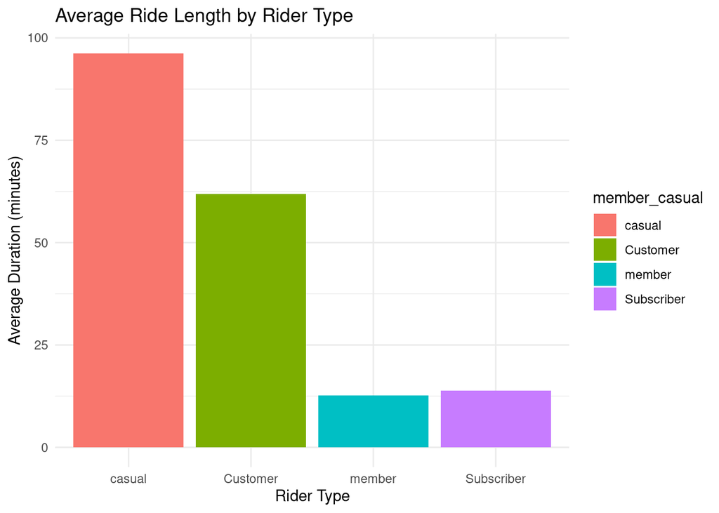

```r
# 5. Share (Visualizations and Key Findings)

##Average Ride Length by Rider Type


  trips_clean %>%
  group_by(member_casual) %>%
  summarise(avg_ride_length = mean(ride_length)) %>%
  ggplot(aes(x = member_casual, y = avg_ride_length, fill = member_casual)) +
  geom_col() +
  labs(title = "Average Ride Length by Rider Type",
       x = "Rider Type",
       y = "Average Duration (minutes)") +
  theme_minimal()
```

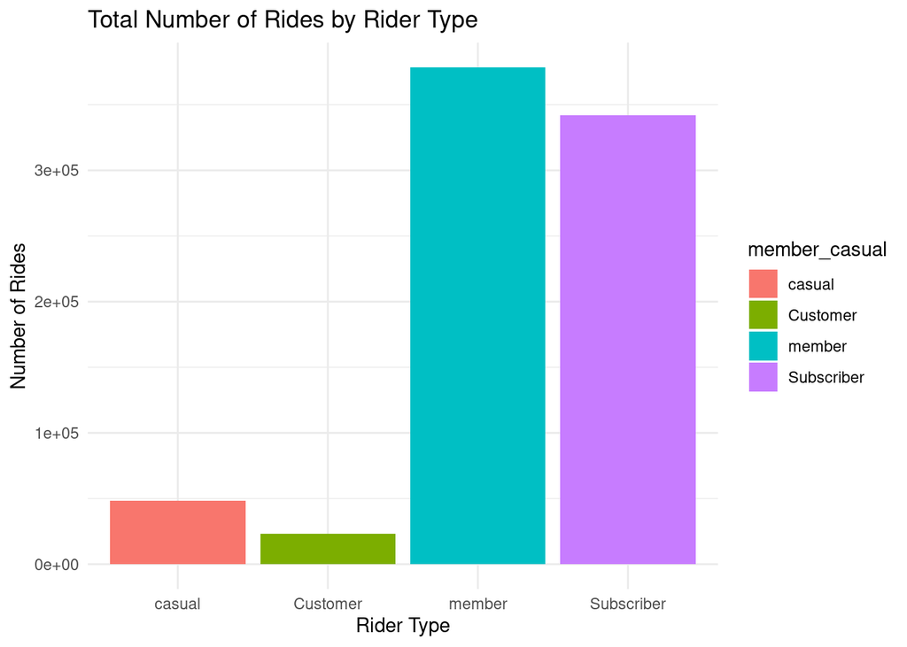

```r
##Number of Rides by Rider Type

  trips_clean %>%
  group_by(member_casual) %>%
  summarise(number_of_rides = n()) %>%
  ggplot(aes(x = member_casual, y = number_of_rides, fill = member_casual)) +
  geom_col() +
  labs(title = "Total Number of Rides by Rider Type",
       x = "Rider Type",
       y = "Number of Rides") +
  theme_minimal()
```

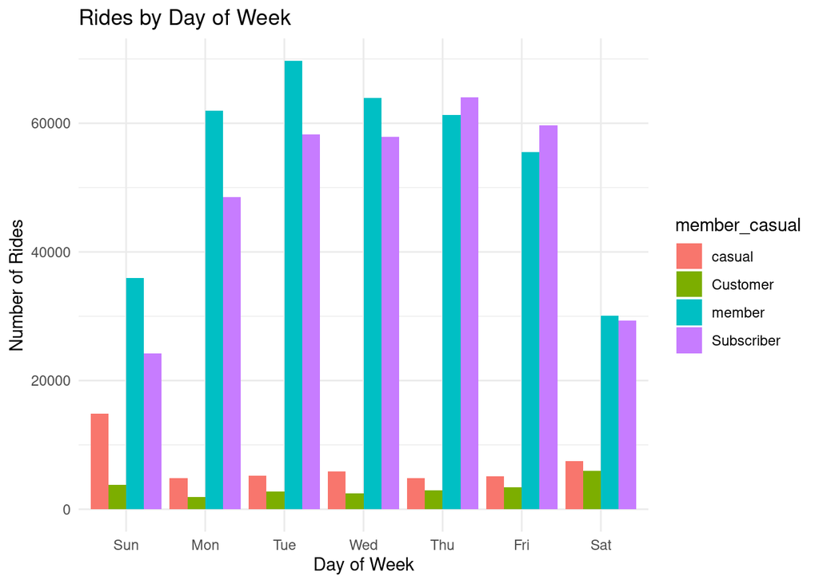

```r
##Rides by Day of Week

  trips_clean %>%
  group_by(day_of_week, member_casual) %>%
  summarise(number_of_rides = n()) %>%
  ggplot(aes(x = day_of_week, y = number_of_rides, fill = member_casual)) +
  geom_col(position = "dodge") +
  labs(title = "Rides by Day of Week",
       x = "Day of Week",
       y = "Number of Rides") +
  theme_minimal()
```

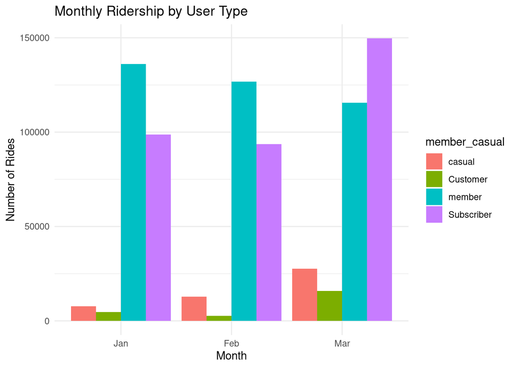

```r
##Seasonal Trend (Months in Q1)

  trips_clean %>%
  mutate(month = month(started_at, label = TRUE)) %>%
  group_by(month, member_casual) %>%
  summarise(number_of_rides = n()) %>%
  ggplot(aes(x = month, y = number_of_rides, fill = member_casual)) +
  geom_col(position = "dodge") +
  labs(title = "Monthly Ridership by User Type",
       x = "Month",
       y = "Number of Rides") +
  theme_minimal()
```

# 6. Act

## Final Conclusion

- The analysis shows that casual riders and annual members use Cyclistic bikes very differently.
- Casual riders take longer trips and ride more on weekends, suggesting leisure use.
- Annual members ride more frequently, especially on weekdays, reflecting commuting behavior.
- To increase profitability, Cyclistic should focus on converting casual riders into members.

## Top 3 Recommendations

1. **Target Casual Riders with Promotions**  
   Launch membership campaigns aimed at casual riders, highlighting cost savings for frequent leisure trips.
2. **Introduce Flexible Memberships**  
   Offer weekend or seasonal passes to attract casual riders who primarily ride for leisure.
3. **Promote Commuting Benefits**  
   Partner with employers to provide subsidized annual memberships, emphasizing convenience and savings for daily travel.